# Comparative Analysis of Statistical Learning Techniques in Tumor classification

Michael Nichols and John Lee

2023-12-08

### Introduction

Breast cancer is the most prevalent form of cancer among women world wide. Current research is focused on early detection of breast cancer as it is the most effective way to significantly improve survival rates. Recent advances in science and machines learning offer promising results in the evaluation of the stage of the tumor and its progression in order to determine the optimal treatment.

This paper presents a comprehensive analysis of various statistical learning techniques applied to the classification of benign and malignant tumors. The diagnosis of tumors as benign of malignant is critical in determining the best treatment and prognosis. Statistical methods offer significant advantages to predict whether a tumor is benign or malignant by leveraging large data sets to make accurate predictions. The data used for this is from the Wisconsin Diagnostic Breast Cancer (WDBC) data set. Various statistical learning procedures were used for prediction.

### Feature Information

1. ID = ID number
2. Diagnosis (M=malignant, B=benign)
3. Radius (mean of the distance from center to points on the perimeter)
4. Texture (standard deviation of gray-scale values)
5. Perimeter
6. Area
7. Smoothness (local variation in radius lengths)
8. Compactness (perimeter^2 / area – 1.0)
9. Concavity (severity of concave portions of the contour)
10. Concave points (number of concave portions of the contour)
11. Symmetry
12. Fractal dimension (“coastline approximation” -1 )

```r
library(tidyverse)
library(MASS)
library(class)
library(e1071)
library(glmnet)
library(boot)
library(randomForest)
library(mgcv)
```

```r
library(rpart)
library(ggplot2)
library(caret)
library(leaps)
library(tree)
library(gbm)
library(BART)
library(knitr)

#for a better HTML file layout
knitr::opts_chunk$set(echo = TRUE, warning = FALSE, message = FALSE)

data <- read.csv("~/Desktop/Stats lab/Final project/Breat Cancer Wisonsin (Diagnostic).csv")

#exclude last column because it is empty
data <- data[, -ncol(data)]

#convert M=Malignant and B=Benign to 1=Malignant and 0=Benign
data$diagnosis <- ifelse(data$diagnosis == 'M', 1,0)

names(data)
```

```
##  [1] "id"                      "diagnosis"
##  [3] "radius_mean"             "texture_mean"
##  [5] "perimeter_mean"          "area_mean"
##  [7] "smoothness_mean"         "compactness_mean"
##  [9] "concavity_mean"          "concave.points_mean"
## [11] "symmetry_mean"           "fractal_dimension_mean"
## [13] "radius_se"               "texture_se"
## [15] "perimeter_se"            "area_se"
## [17] "smoothness_se"           "compactness_se"
## [19] "concavity_se"            "concave.points_se"
## [21] "symmetry_se"             "fractal_dimension_se"
## [23] "radius_worst"            "texture_worst"
## [25] "perimeter_worst"         "area_worst"
## [27] "smoothness_worst"        "compactness_worst"
## [29] "concavity_worst"         "concave.points_worst"
## [31] "symmetry_worst"          "fractal_dimension_worst"
```

```r
summary(data)
```

```
##        id              diagnosis       radius_mean      texture_mean
##  Min.   :     8670   Min.   :0.0000   Min.   : 6.981   Min.   : 9.71
##  1st Qu.:   869218   1st Qu.:0.0000   1st Qu.:11.700   1st Qu.:16.17
##  Median :   906024   Median :0.0000   Median :13.370   Median :18.84
##  Mean   : 30371831   Mean   :0.3726   Mean   :14.127   Mean   :19.29
##  3rd Qu.:  8813129   3rd Qu.:1.0000   3rd Qu.:15.780   3rd Qu.:21.80
##  Max.   :911320502   Max.   :1.0000   Max.   :28.110   Max.   :39.28
##  perimeter_mean     area_mean      smoothness_mean   compactness_mean
##  Min.   : 43.79   Min.   : 143.5   Min.   :0.05263   Min.   :0.01938
##  1st Qu.: 75.17   1st Qu.: 420.3   1st Qu.:0.08637   1st Qu.:0.06492
##  Median : 86.24   Median : 551.1   Median :0.09587   Median :0.09263
##  Mean   : 91.97   Mean   : 654.9   Mean   :0.09636   Mean   :0.10434
##  3rd Qu.:104.10   3rd Qu.: 782.7   3rd Qu.:0.10530   3rd Qu.:0.13040
##  Max.   :188.50   Max.   :2501.0   Max.   :0.16340   Max.   :0.34540
##  concavity_mean    concave.points_mean symmetry_mean    fractal_dimension_mean
##  Min.   :0.00000   Min.   :0.00000     Min.   :0.1060   Min.   :0.04996
##  1st Qu.:0.02956   1st Qu.:0.02031     1st Qu.:0.1619   1st Qu.:0.05770
##  Median :0.06154   Median :0.03350     Median :0.1792   Median :0.06154
##  Mean   :0.08880   Mean   :0.04892     Mean   :0.1812   Mean   :0.06280
##  3rd Qu.:0.13070   3rd Qu.:0.07400     3rd Qu.:0.1957   3rd Qu.:0.06612
##  Max.   :0.42680   Max.   :0.20120     Max.   :0.3040   Max.   :0.09744
##    radius_se        texture_se      perimeter_se       area_se
##  Min.   :0.1115   Min.   :0.3602   Min.   : 0.757   Min.   :  6.802
##  1st Qu.:0.2324   1st Qu.:0.8339   1st Qu.: 1.606   1st Qu.: 17.850
##  Median :0.3242   Median :1.1080   Median : 2.287   Median : 24.530
##  Mean   :0.4052   Mean   :1.2169   Mean   : 2.866   Mean   : 40.337
##  3rd Qu.:0.4789   3rd Qu.:1.4740   3rd Qu.: 3.357   3rd Qu.: 45.190
##  Max.   :2.8730   Max.   :4.8850   Max.   :21.980   Max.   :542.200
##  smoothness_se      compactness_se      concavity_se     concave.points_se
##  Min.   :0.001713   Min.   :0.002252   Min.   :0.00000   Min.   :0.000000
##  1st Qu.:0.005169   1st Qu.:0.013080   1st Qu.:0.01509   1st Qu.:0.007638
##  Median :0.006380   Median :0.020450   Median :0.02589   Median :0.010930
##  Mean   :0.007041   Mean   :0.025478   Mean   :0.03189   Mean   :0.011796
##  3rd Qu.:0.008146   3rd Qu.:0.032450   3rd Qu.:0.04205   3rd Qu.:0.014710
##  Max.   :0.031130   Max.   :0.135400   Max.   :0.39600   Max.   :0.052790
##   symmetry_se       fractal_dimension_se  radius_worst   texture_worst
##  Min.   :0.007882   Min.   :0.0008948    Min.   : 7.93   Min.   :12.02
##  1st Qu.:0.015160   1st Qu.:0.0022480    1st Qu.:13.01   1st Qu.:21.08
##  Median :0.018730   Median :0.0031870    Median :14.97   Median :25.41
##  Mean   :0.020542   Mean   :0.0037949    Mean   :16.27   Mean   :25.68
##  3rd Qu.:0.023480   3rd Qu.:0.0045580    3rd Qu.:18.79   3rd Qu.:29.72
##  Max.   :0.078950   Max.   :0.0298400    Max.   :36.04   Max.   :49.54
##  perimeter_worst    area_worst     smoothness_worst  compactness_worst
##  Min.   : 50.41   Min.   : 185.2   Min.   :0.07117   Min.   :0.02729
##  1st Qu.: 84.11   1st Qu.: 515.3   1st Qu.:0.11660   1st Qu.:0.14720
##  Median : 97.66   Median : 686.5   Median :0.13130   Median :0.21190
##  Mean   :107.26   Mean   : 880.6   Mean   :0.13237   Mean   :0.25427
##  3rd Qu.:125.40   3rd Qu.:1084.0   3rd Qu.:0.14600   3rd Qu.:0.33910
##  Max.   :251.20   Max.   :4254.0   Max.   :0.22260   Max.   :1.05800
##  concavity_worst  concave.points_worst symmetry_worst   fractal_dimension_worst
##  Min.   :0.0000   Min.   :0.00000      Min.   :0.1565   Min.   :0.05504
##  1st Qu.:0.1145   1st Qu.:0.06493      1st Qu.:0.2504   1st Qu.:0.07146
##  Median :0.2267   Median :0.09993      Median :0.2822   Median :0.08004
##  Mean   :0.2722   Mean   :0.11461      Mean   :0.2901   Mean   :0.08395
##  3rd Qu.:0.3829   3rd Qu.:0.16140      3rd Qu.:0.3179   3rd Qu.:0.09208
##  Max.   :1.2520   Max.   :0.29100      Max.   :0.6638   Max.   :0.20750
```

```r
dim(data)
```

```
## [1] 569  32
```

```r
#took out the first column because it is the patient id
cor(data[,-1])
```

```
##                            diagnosis  radius_mean texture_mean perimeter_mean
## diagnosis                1.000000000  0.730028511  0.415185300    0.742635530
## radius_mean              0.730028511  1.000000000  0.323781891    0.997855281
## texture_mean             0.415185300  0.323781891  1.000000000    0.329533059
## perimeter_mean           0.742635530  0.997855281  0.329533059    1.000000000
## area_mean                0.708983837  0.987357170  0.321085696    0.986506804
## smoothness_mean          0.358559965  0.170581187 -0.023388516    0.207278164
## compactness_mean         0.596533678  0.506123578  0.236702222    0.556936211
## concavity_mean           0.696359707  0.676763550  0.302417828    0.716135650
## concave.points_mean      0.776613840  0.822528522  0.293464051    0.850977041
## symmetry_mean            0.330498554  0.147741242  0.071400980    0.183027212
## fractal_dimension_mean  -0.012837603 -0.311630826 -0.076437183   -0.261476908
## radius_se                0.567133821  0.679090388  0.275868676    0.691765014
## texture_se              -0.008303333 -0.097317443  0.386357623   -0.086761078
## perimeter_se             0.556140703  0.674171616  0.281673115    0.693134890
## area_se                  0.548235940  0.735863663  0.259844987    0.744982694
## smoothness_se           -0.067016011 -0.222600125  0.006613777   -0.202694026
## compactness_se           0.292999244  0.205999980  0.191974611    0.250743681
## concavity_se             0.253729766  0.194203623  0.143293077    0.228082345
## concave.points_se        0.408042333  0.376168956  0.163851025    0.407216916
## symmetry_se             -0.006521756 -0.104320881  0.009127168   -0.081629327
## fractal_dimension_se     0.077972417 -0.042641269  0.054457520   -0.005523391
## radius_worst             0.776453779  0.969538973  0.352572947    0.969476363
## texture_worst            0.456902821  0.297007644  0.912044589    0.303038372
## perimeter_worst          0.782914137  0.965136514  0.358039575    0.970386887
## area_worst               0.733825035  0.941082460  0.343545947    0.941549808
## smoothness_worst         0.421464861  0.119616140  0.077503359    0.150549404
## compactness_worst        0.590998238  0.413462823  0.277829592    0.455774228
## concavity_worst          0.659610210  0.526911462  0.301025224    0.563879263
## concave.points_worst     0.793566017  0.744214198  0.295315843    0.771240789
## symmetry_worst           0.416294311  0.163953335  0.105007910    0.189115040
## fractal_dimension_worst  0.323872189  0.007065886  0.119205351    0.051018530
##                            area_mean smoothness_mean compactness_mean
## diagnosis                0.708983837      0.35855997       0.59653368
## radius_mean              0.987357170      0.17058119       0.50612358
## texture_mean             0.321085696     -0.02338852       0.23670222
## perimeter_mean           0.986506804      0.20727816       0.55693621
## area_mean                1.000000000      0.17702838       0.49850168
## smoothness_mean          0.177028377      1.00000000       0.65912322
## compactness_mean         0.498501682      0.65912322       1.00000000
```

[output cut: 265 more lines]

```
## compactness_se              0.27787843             0.590972763
## concavity_se                0.19778782             0.439329269
## concave.points_se           0.14311567             0.310654551
## symmetry_se                 0.38940248             0.078079476
## fractal_dimension_se        0.11109396             0.591328066
## radius_worst                0.24352920             0.093491979
## texture_worst               0.23302746             0.219122425
## perimeter_worst             0.26949277             0.138956862
## area_worst                  0.20914551             0.079647034
## smoothness_worst            0.49383833             0.617624192
## compactness_worst           0.61444050             0.810454856
## concavity_worst             0.53251973             0.686510921
## concave.points_worst        0.50252849             0.511114146
## symmetry_worst              1.00000000             0.537848206
## fractal_dimension_worst     0.53784821             1.000000000
```

It appear that there is notable correlation between all variables except fractal_dimension_mean, texture_se, smoothness_se, symmetry_se, and fractal_dimension_se and diagnosis, that is the correlation is close to 0.

[output not shown]

```
##
## Call:
## lm(formula = diagnosis ~ . - id, data = data)
##
## Residuals:
##      Min       1Q   Median       3Q      Max
## -0.60241 -0.16209 -0.02705  0.12982  0.82295
##
## Coefficients:
##                           Estimate Std. Error t value Pr(>|t|)
## (Intercept)             -2.0218117  0.4280072  -4.724 2.96e-06 ***
## radius_mean             -0.2177721  0.1735089  -1.255 0.209985
## texture_mean             0.0045455  0.0079439   0.572 0.567426
## perimeter_mean           0.0237399  0.0250985   0.946 0.344641
## area_mean                0.0003178  0.0005253   0.605 0.545391
## smoothness_mean          0.0846891  2.0172759   0.042 0.966529
## compactness_mean        -4.2220353  1.3336803  -3.166 0.001635 **
## concavity_mean           1.3979973  1.0458611   1.337 0.181887
## concave.points_mean      2.1418330  1.9791819   1.082 0.279657
## symmetry_mean            0.1027092  0.7427382   0.138 0.890067
## fractal_dimension_mean   0.0332616  5.5722693   0.006 0.995240
## radius_se                0.4349559  0.3104682   1.401 0.161800
## texture_se              -0.0067585  0.0368439  -0.183 0.854525
## perimeter_se            -0.0225203  0.0411183  -0.548 0.584129
## area_se                 -0.0009232  0.0013978  -0.660 0.509235
## smoothness_se           15.8543207  6.6248737   2.393 0.017046 *
## compactness_se           0.0649034  2.1694829   0.030 0.976145
## concavity_se            -3.5654680  1.3007522  -2.741 0.006327 **
## concave.points_se       10.5679513  5.4520354   1.938 0.053103 .
## symmetry_se              1.6973407  2.7276006   0.622 0.534019
## fractal_dimension_se    -7.1464402 11.6764096  -0.612 0.540769
## radius_worst             0.1951831  0.0579677   3.367 0.000814 ***
## texture_worst            0.0071594  0.0069489   1.030 0.303339
## perimeter_worst         -0.0024351  0.0059360  -0.410 0.681807
## area_worst              -0.0010112  0.0003197  -3.163 0.001648 **
## smoothness_worst         0.5428569  1.4346393   0.378 0.705288
## compactness_worst        0.0671583  0.3830830   0.175 0.860902
## concavity_worst          0.3811912  0.2686173   1.419 0.156453
## concave.points_worst     0.4643099  0.9142253   0.508 0.611751
## symmetry_worst           0.5567875  0.4943014   1.126 0.260493
## fractal_dimension_worst  4.3034831  2.3832134   1.806 0.071517 .
## ---
## Signif. codes:  0 '***' 0.001 '**' 0.01 '*' 0.05 '.' 0.1 ' ' 1
##
## Residual standard error: 0.2362 on 538 degrees of freedom
## Multiple R-squared:  0.7743, Adjusted R-squared:  0.7617
## F-statistic: 61.53 on 30 and 538 DF,  p-value: < 2.2e-16
```

We see that even at the 10% significance level only the intercept, compactness_mean, smoothness_se, concavity_se, concave.points_se, radius_worst, area_worst, and fractal_dimension_worst are significant. We can determine which predictors are associated with the response through subset selection later on. We also see that the R^2 is .7743 which is not bad but can be improved upon.

```r
#showing that some of the predicted probabilities are outside of [0,1]
preds <- predict(lin.reg, data)
out_of_bounds_predictions <- preds[preds < 0 | preds > 1]
head(out_of_bounds_predictions)
```

```
##        1        3        4       10       18       19
## 1.045575 1.131320 1.192288 1.154653 1.015990 1.068665
```

This highlights one of the major downfalls when using linear regression for classification problems. Despite the response being a binary variable, some of the probabilities fall outside of the range [0,1] interval which are hard to interpret as probabilities.

### Logistic Regression

```r
##Logistic regression
glm.fit <- glm(diagnosis ~ . -id, family = binomial, data=data)
summary(glm.fit)
```

```
##
## Call:
## glm(formula = diagnosis ~ . - id, family = binomial, data = data)
##
## Coefficients:
##                           Estimate Std. Error z value Pr(>|z|)
## (Intercept)             -2.881e+06  2.816e+05 -10.233  < 2e-16 ***
## radius_mean              2.427e+06  2.693e+05   9.014  < 2e-16 ***
## texture_mean             1.958e+05  1.471e+04  13.313  < 2e-16 ***
## perimeter_mean           1.473e+06  2.464e+04  59.791  < 2e-16 ***
## area_mean               -1.301e+05  3.907e+03 -33.301  < 2e-16 ***
## smoothness_mean         -1.525e+08  8.361e+06 -18.234  < 2e-16 ***
## compactness_mean        -6.428e+06  3.213e+06  -2.001  0.04539 *
## concavity_mean           1.042e+06  1.408e+06   0.740  0.45959
## concave.points_mean     -1.716e+07  5.382e+06  -3.188  0.00143 **
## symmetry_mean            4.049e+07  7.772e+05  52.093  < 2e-16 ***
## fractal_dimension_mean  -4.233e+07  2.169e+06 -19.519  < 2e-16 ***
## radius_se                3.328e+07  1.169e+06  28.478  < 2e-16 ***
## texture_se               6.368e+06  2.005e+05  31.763  < 2e-16 ***
## perimeter_se             1.701e+06  4.720e+04  36.032  < 2e-16 ***
## area_se                 -6.393e+05  1.835e+04 -34.840  < 2e-16 ***
## smoothness_se            7.492e+08  1.224e+07  61.213  < 2e-16 ***
## compactness_se          -1.773e+08  5.732e+06 -30.931  < 2e-16 ***
## concavity_se             1.529e+08  5.340e+06  28.624  < 2e-16 ***
## concave.points_se       -1.260e+09  4.012e+07 -31.398  < 2e-16 ***
## symmetry_se              2.890e+08  4.126e+06  70.055  < 2e-16 ***
## fractal_dimension_se     1.512e+09  6.597e+07  22.921  < 2e-16 ***
## radius_worst            -6.130e+06  2.143e+05 -28.606  < 2e-16 ***
## texture_worst           -5.832e+05  2.437e+04 -23.935  < 2e-16 ***
## perimeter_worst         -3.538e+05  1.219e+04 -29.023  < 2e-16 ***
## area_worst               8.950e+04  2.741e+03  32.658  < 2e-16 ***
## smoothness_worst        -2.161e+07  3.298e+06  -6.553 5.66e-11 ***
## compactness_worst        8.986e+06  3.999e+05  22.470  < 2e-16 ***
## concavity_worst         -3.028e+07  1.523e+06 -19.875  < 2e-16 ***
## concave.points_worst     1.431e+08  5.471e+06  26.162  < 2e-16 ***
## symmetry_worst          -2.474e+07  3.392e+05 -72.923  < 2e-16 ***
## fractal_dimension_worst -3.698e+07  5.340e+06  -6.926 4.33e-12 ***
## ---
## Signif. codes:  0 '***' 0.001 '**' 0.01 '*' 0.05 '.' 0.1 ' ' 1
##
## (Dispersion parameter for binomial family taken to be 1)
##
##     Null deviance:   751.44  on 568  degrees of freedom
## Residual deviance: 32006.76  on 538  degrees of freedom
## AIC: 32069
##
## Number of Fisher Scoring iterations: 25
```

All varialbes except for concavity_mean are significant at the 5% level. Now, we predict the probability that a tumor is benign or malignant on the training data

```r
glm.probs <- predict(glm.fit, type = "response")
glm.prob.logit <- predict (glm.fit)

#create a vector of class predictions based on whether the predicted probability of a malignant tumor is greater than or less than 0.5
glm.pred <- rep("0", 569)
glm.pred[glm.probs >.5] = "1"

#confusion matrix
table(glm.pred, data$diagnosis)
```

```
##
## glm.pred   0   1
##        0  68 155
##        1 289  57
```

```r
mean(glm.pred == data$diagnosis)
```

```
## [1] 0.2196837
```

Lets modify the threshold for classification. We want to be conservative in our predictions of individuals who have malignant tumors, while still to be avoided, an incorrect classificatioin of a benign tumor as malignant is less important. Upon looking at the predictions, most are very close to 0 (10^-15) or very close to 1 so this is where we set our threshold.

```r
glm.pred2 <- rep("0", 569)
glm.pred2[glm.probs >.00000000001] = "1"

#confusion matrix
table(glm.pred2, data$diagnosis)
```

```
##
## glm.pred2   0   1
##         0  62 155
##         1 295  57
```

```r
mean(glm.pred2 == data$diagnosis)
```

```
## [1] 0.2091388
```

57+62/569=.2091 or 20.91% correctly predicted. This lowered threshold actually performs worse than the previous which was not expected. This may because we are trying to predict a binary response using multiple highly correlated predictors. For example, a mass with a large mean perimeter likely has a large mean area. However, these results are more likely due to the assumption that there is a linear relationship between the log odds and the predictors thus I will explore feature selection, regularization, and decision trees later on.

Now we create random training and test sets (chose to split the data at the 3rd quartile of the most highly correlated variable with diagnosis) using the validation set approach for an estimate of the test error rate. We do this for Logistic Regression, LDA, QDA, KNN, and Naive Bayes. We are not concerned with an estimate of the training error rate. We want to create a model that performs well on a new independent data point rather than a model that performs well on a observations that was used to train the model. For the rest of this study, we will focus on test error rates.

```r
set.seed(1)
train <- (data$concave.points_worst < 0.16140)
test <- data[!train,]
test_diagnosis <- data$diagnosis[!train]
dim(test)
```

```
## [1] 143  32
```

```r
#fit logistic regression model using only training set
glm.fit2 <- glm(diagnosis ~ . -id, data = data, family = binomial, subset = train)
glm.probs2 <- predict(glm.fit2, test, type = "response")
glm.pred3 <- rep("0",143)
glm.pred3[glm.probs2 >.5] <- "1"
table(glm.pred3, test_diagnosis)
```

```
##          test_diagnosis
## glm.pred3   0   1
##         0   1   9
##         1   1 132
```

```r
mean(glm.pred3 == test_diagnosis)
```

```
## [1] 0.9300699
```

```r
mean(glm.pred3 != test_diagnosis)
```

```
## [1] 0.06993007
```

132+1/143= .9301 or 93.01% correctly predicted and we have an error rate of 6.99% which is actually quite good. This is promising considering the results from the earlier stage of analysis. However, may be due to where I split the data.

### Linear Discriminant Analysis

```r
lda.fit <- lda(diagnosis ~ . -id, data = data, subset = train)
lda.fit
```

```
## Call:
## lda(diagnosis ~ . - id, data = data, subset = train)
##
## Prior probabilities of groups:
##         0         1
## 0.8333333 0.1666667
##
## Group means:
##   radius_mean texture_mean perimeter_mean area_mean smoothness_mean
## 0    12.15194     17.92220       78.10603  463.2270      0.09239470
## 1    16.31859     21.45408      106.33338  852.0366      0.09589592
##   compactness_mean concavity_mean concave.points_mean symmetry_mean
## 0       0.07970538     0.04510611          0.02554224     0.1740256
## 1       0.10299155     0.10331958          0.06064028     0.1801676
##   fractal_dimension_mean radius_se texture_se perimeter_se  area_se
## 0             0.06280051 0.2839549   1.221030     2.001957 21.16794
## 1             0.05896211 0.5248000   1.220945     3.589634 57.96930
##   smoothness_se compactness_se concavity_se concave.points_se symmetry_se
## 0   0.007190406     0.02121590   0.02517531       0.009780654  0.02052143
## 1   0.006844155     0.02333404   0.03275141       0.012640000  0.01896482
##   fractal_dimension_se radius_worst texture_worst perimeter_worst area_worst
## 0          0.003616643     13.38239      23.51842        87.03932   559.4014
## 1          0.003263042     19.06465      28.69775       125.22394  1144.1718
##   smoothness_worst compactness_worst concavity_worst concave.points_worst
## 0        0.1248134         0.1811225       0.1622791           0.07388966
## 1        0.1337999         0.2507889       0.3068575           0.13291704
##   symmetry_worst fractal_dimension_worst
## 0      0.2695839              0.07927245
## 1      0.2938380              0.07984423
##
## Coefficients of linear discriminants:
##                                   LD1
## radius_mean             -1.771048e+00
## texture_mean             5.874840e-02
## perimeter_mean           2.715279e-01
## area_mean               -5.648998e-03
## smoothness_mean          2.264876e+01
## compactness_mean        -2.866465e+01
## concavity_mean           1.536843e+01
## concave.points_mean      1.590774e+01
## symmetry_mean           -5.070768e+00
## fractal_dimension_mean   8.853911e+00
## radius_se                5.126614e+00
## texture_se              -1.265927e-01
## perimeter_se            -2.623317e-01
## area_se                 -2.552496e-02
## smoothness_se            9.052027e+01
## compactness_se           6.818914e+00
## concavity_se            -2.029992e+01
## concave.points_se        6.565958e+01
## symmetry_se             -2.067972e+01
## fractal_dimension_se    -1.143047e+02
## radius_worst            -1.956315e-01
## texture_worst            1.947893e-02
## perimeter_worst         -2.595707e-02
## area_worst               1.209171e-02
## smoothness_worst        -1.036320e+01
## compactness_worst        8.448768e-03
## concavity_worst          1.700653e+00
## concave.points_worst    -7.634484e+00
## symmetry_worst           7.593775e+00
## fractal_dimension_worst  2.438607e+01
```

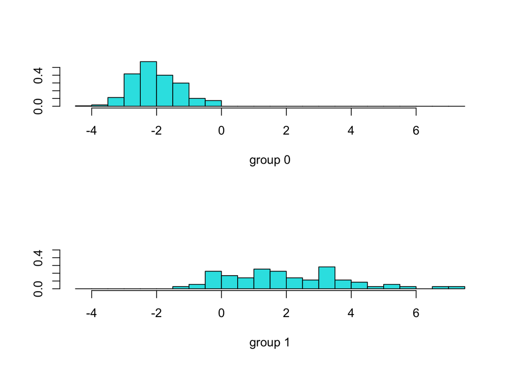

```r
plot(lda.fit)
```

```r
lda.pred <- predict(lda.fit, test)
lda.class <- lda.pred$class
table(lda.class, test_diagnosis)
```

```
##          test_diagnosis
## lda.class   0   1
##         0   2   6
##         1   0 135
```

```r
mean(lda.class == test_diagnosis)
```

```
## [1] 0.958042
```

135+2/143 = .9580 or 95.80% correctly predicted.

### Quadratic Discriminant Analysis

```r
qda.fit <- qda(diagnosis ~ . -id, data=data, subset = train)
qda.fit
```

```
## Call:
## qda(diagnosis ~ . - id, data = data, subset = train)
##
## Prior probabilities of groups:
##         0         1
## 0.8333333 0.1666667
##
## Group means:
##   radius_mean texture_mean perimeter_mean area_mean smoothness_mean
## 0    12.15194     17.92220       78.10603  463.2270      0.09239470
## 1    16.31859     21.45408      106.33338  852.0366      0.09589592
##   compactness_mean concavity_mean concave.points_mean symmetry_mean
## 0       0.07970538     0.04510611          0.02554224     0.1740256
## 1       0.10299155     0.10331958          0.06064028     0.1801676
##   fractal_dimension_mean radius_se texture_se perimeter_se  area_se
## 0             0.06280051 0.2839549   1.221030     2.001957 21.16794
## 1             0.05896211 0.5248000   1.220945     3.589634 57.96930
##   smoothness_se compactness_se concavity_se concave.points_se symmetry_se
## 0   0.007190406     0.02121590   0.02517531       0.009780654  0.02052143
## 1   0.006844155     0.02333404   0.03275141       0.012640000  0.01896482
##   fractal_dimension_se radius_worst texture_worst perimeter_worst area_worst
## 0          0.003616643     13.38239      23.51842        87.03932   559.4014
## 1          0.003263042     19.06465      28.69775       125.22394  1144.1718
##   smoothness_worst compactness_worst concavity_worst concave.points_worst
## 0        0.1248134         0.1811225       0.1622791           0.07388966
## 1        0.1337999         0.2507889       0.3068575           0.13291704
##   symmetry_worst fractal_dimension_worst
## 0      0.2695839              0.07927245
## 1      0.2938380              0.07984423
```

```r
qda.class <- predict(qda.fit, test)$class
table(qda.class, test_diagnosis)
```

```
##          test_diagnosis
## qda.class   0   1
##         0   1  12
##         1   1 129
```

```r
mean(qda.class == test_diagnosis)
```

```
## [1] 0.9090909
```

129+1/143 = .9091 or 90.91% correctly predicted

### K-Nearest Neighbors

```r
# Splitting data into training and testing sets
set.seed(1)
trainIndex <- sample(1:nrow(data), 0.7 * nrow(data))
trainData <- data[trainIndex, ]
testData <- data[-trainIndex, ]

trainLabel <- trainData$diagnosis
testLabel <- testData$diagnosis
trainData <- trainData[, -which(names(trainData) == "diagnosis")]
testData <- testData[, -which(names(testData) == "diagnosis")]

#k=1
k <- 1
knn.model <- knn(trainData, testData, cl = trainLabel, k = k)
knn.table <- table(Predicted = knn.model, Actual = testLabel)
knn.table
```

```
##          Actual
## Predicted  0  1
##         0 94 22
##         1  9 46
```

94+46/171 = .8187 or 81.87% correctly predicted

```r
#k=3
k<-3
knn.model <- knn(trainData, testData, cl = trainLabel, k = k)
knn.table <- table(Predicted = knn.model, Actual = testLabel)
knn.table
```

```
##          Actual
## Predicted  0  1
##         0 90 35
##         1 13 33
```

### Naive Bayes

```r
nb.fit <- naiveBayes(diagnosis ~ . -id, data = data, subset = train)
nb.fit
```

```
##
## Naive Bayes Classifier for Discrete Predictors
##
## Call:
## naiveBayes.default(x = X, y = Y, laplace = laplace)
##
## A-priori probabilities:
## Y
##         0         1
## 0.8333333 0.1666667
##
## Conditional probabilities:
##    radius_mean
## Y       [,1]     [,2]
##   0 12.15194 1.776689
##   1 16.31859 2.724525
##
##    texture_mean
## Y       [,1]     [,2]
##   0 17.92220 4.004778
##   1 21.45408 2.923822
##
##    perimeter_mean
## Y        [,1]     [,2]
##   0  78.10603 11.78778
##   1 106.33338 18.27485
##
##    area_mean
## Y       [,1]     [,2]
##   0 463.2270 134.1572
##   1 852.0366 307.7130
##
##    smoothness_mean
## Y         [,1]       [,2]
##   0 0.09239470 0.01343819
##   1 0.09589592 0.01094926
##
##    compactness_mean
## Y         [,1]       [,2]
##   0 0.07970538 0.03345952
```

[output cut: 106 more lines]

```
##
##    concave.points_worst
## Y         [,1]       [,2]
##   0 0.07388966 0.03512254
##   1 0.13291704 0.02682125
##
##    symmetry_worst
## Y        [,1]       [,2]
##   0 0.2695839 0.04082994
##   1 0.2938380 0.06201685
##
##    fractal_dimension_worst
## Y         [,1]       [,2]
##   0 0.07927245 0.01364261
##   1 0.07984423 0.01622219
```

```r
nb.class <- predict(nb.fit, test)
table(nb.class, test_diagnosis)
```

```
##         test_diagnosis
## nb.class   0   1
##        0   1   0
##        1   1 141
```

```r
mean(nb.class == test_diagnosis)
```

```
## [1] 0.993007
```

141+1/143=.9930 or 99.30% correctly predicted. Naive Bayes performed the best out of all of the generative models for classification which is not expected. We expect better results from naive bayes relative to using LDA or QDA in an instance where p (number of predictors) is larger and n (sample size) is smaller, which is not the case for this data set.

Naive Bayes performed the best out of all of the generative models for classification which is not expected. We expect better results from naive bayes relative to using LDA or QDA in an instance where p is larger and n is smaller, which is not the case for this data set. LDA and logistic regression also performed very well.

We were very skeptical of the test error estimates obtained above (validatioin set approach) so we proceeded with leave out out cross validation (LOOCV) to verify the test error estimates. We did this beucase we got very low test error rates when our training error rates were very high so eliminating the randomness, through LOOCV, in the split of the data would yield more trustworthy results.

## Leave One Out Cross Validation

### Logistic regression

```r
errors <- rep(0, nrow(data))
for (i in 1:nrow(data)) {
  glm.log <- glm(diagnosis ~ . -id, data = data[-i, ], family = binomial)

  glm.problog <- predict(glm.log, newdata = data[i, ], type = "response")

  errors[i] <- (glm.problog > 0.5) != (data$diagnosis[i] == "1")
}
loocv_error <- mean(errors)
loocv_error
```

```
## [1] 0.3427065
```

LOOCV test error estimate for Logistic regression: 0.3427065

### LDA

```r
errors_lda <- rep(0, nrow(data))
for (i in 1:nrow(data)) {
  lda.fit <- lda(diagnosis ~ . -id, data = data[-i, ])
  lda.pred <- predict(lda.fit, newdata = data[i, ])$class
  errors_lda[i] <- lda.pred != data$diagnosis[i]
}
loocv_error_lda <- mean(errors_lda)
loocv_error_lda
```

```
## [1] 0.04217926
```

LOOCV test error estimate for LDA: 0.04217926

### QDA

```r
errors_qda <- rep(0, nrow(data))
for (i in 1:nrow(data)) {
  qda.fit <- qda(diagnosis ~ . -id, data = data[-i, ])
  qda.pred <- predict(qda.fit, newdata = data[i, ])$class
  errors_qda[i] <- qda.pred != data$diagnosis[i]
}
loocv_error_qda <- mean(errors_qda)
loocv_error_qda
```

```
## [1] 0.04393673
```

LOOCV test error estimate for QDA: 0.04393673

### KNN

```r
errors_knn <- rep(0, nrow(data))
for (i in 1:nrow(data)) {
  trainData <- data[-i, -which(names(data) == "diagnosis")]
  testData <- data[i, -which(names(data) == "diagnosis")]
  trainLabel <- data$diagnosis[-i]
  testLabel <- data$diagnosis[i]

  k <- 1
  knn.pred <- knn(trainData, testData, cl = trainLabel, k = k)
  errors_knn[i] <- knn.pred != testLabel
}
loocv_error_knn <- mean(errors_knn)
loocv_error_knn
```

```
## [1] 0.1564148
```

LOOCV test error estimate for KNN: 0.1564148

### Naive Bayes

```r
errors_nb <- rep(0, nrow(data))
for (i in 1:nrow(data)) {
  nb.fit <- naiveBayes(diagnosis ~ . -id, data = data[-i, ])
  nb.pred <- predict(nb.fit, newdata = data[i, ])
  errors_nb[i] <- nb.pred != data$diagnosis[i]
}
loocv_error_nb <- mean(errors_nb)
loocv_error_nb
```

```
## [1] 0.06678383
```

LOOCV test error estimate for naive bayes: 0.06678383

All methods have relatively low test error rates but it is clear that LDA and QDA perform the best followed by naive bayes. KNN yields a test error rate of 15.64% and logistic regression yields a test error rate of 34.27%. It is likely that LDA is the optimal model for classification prediction as simpler is often better. LDA is a much less flexible classifier than QDA, and has lower variance. We determined that the optimal model is most likely LDA through analysis of the test error rates but we can now use K-fold cross validation to iterate over all the model and plot them against each other to obtain a result that is less biased.

## K-fold CV for determination of optimal model (generative models for classification)

```r
data$diagnosis <- as.factor(data$diagnosis) # ensure diagnosis is a factor
data <- data[, -which(names(data) == "id")]

# Define a control function for 10-fold cross-validation
control <- trainControl(method = "cv", number = 10)

# Set up a list to store models
models <- list()

# Logistic Regression
set.seed(1)
models$logistic <- train(diagnosis ~ ., data = data, method = "glm", family = "binomial", trControl = control)

# LDA
set.seed(1)
models$lda <- train(diagnosis ~ ., data = data, method = "lda", trControl = control)

# QDA
set.seed(1)
models$qda <- train(diagnosis ~ ., data = data, method = "qda", trControl = control)

# KNN (tuning for the best k)
set.seed(1)
knnGrid <- expand.grid(.k = 1:20) #k from 1 to 20
models$knn <- train(diagnosis ~ ., data = data, method = "knn", tuneGrid = knnGrid, trControl = control)

# Naive Bayes
set.seed(1)
models$naivebayes <- train(diagnosis ~ ., data = data, method = "naive_bayes", trControl = control)

# Review the results
results <- resamples(models)
summary(results)
```

```
##
## Call:
## summary.resamples(object = results)
##
## Models: logistic, lda, qda, knn, naivebayes
## Number of resamples: 10
##
## Accuracy
##                 Min.   1st Qu.    Median      Mean   3rd Qu.      Max. NA's
## logistic   0.8947368 0.9126588 0.9642857 0.9456691 0.9653660 0.9824561    0
## lda        0.9122807 0.9522783 0.9645990 0.9562257 0.9649123 0.9824561    0
## qda        0.9107143 0.9466635 0.9561404 0.9543471 0.9653660 1.0000000    0
## knn        0.8771930 0.9298246 0.9387315 0.9385263 0.9607532 0.9821429    0
## naivebayes 0.8771930 0.9288847 0.9392015 0.9384334 0.9647556 0.9655172    0
##
## Kappa
##                 Min.   1st Qu.    Median      Mean   3rd Qu.      Max. NA's
## logistic   0.7738095 0.8138413 0.9245216 0.8841884 0.9265933 0.9622642    0
## lda        0.8016701 0.8974615 0.9227035 0.9037376 0.9230769 0.9622642    0
## qda        0.8113208 0.8840196 0.9067460 0.9027645 0.9252382 1.0000000    0
## knn        0.7223382 0.8437699 0.8716195 0.8662758 0.9156746 0.9622642    0
## naivebayes 0.7223382 0.8495216 0.8696534 0.8673996 0.9250760 0.9260700    0
```

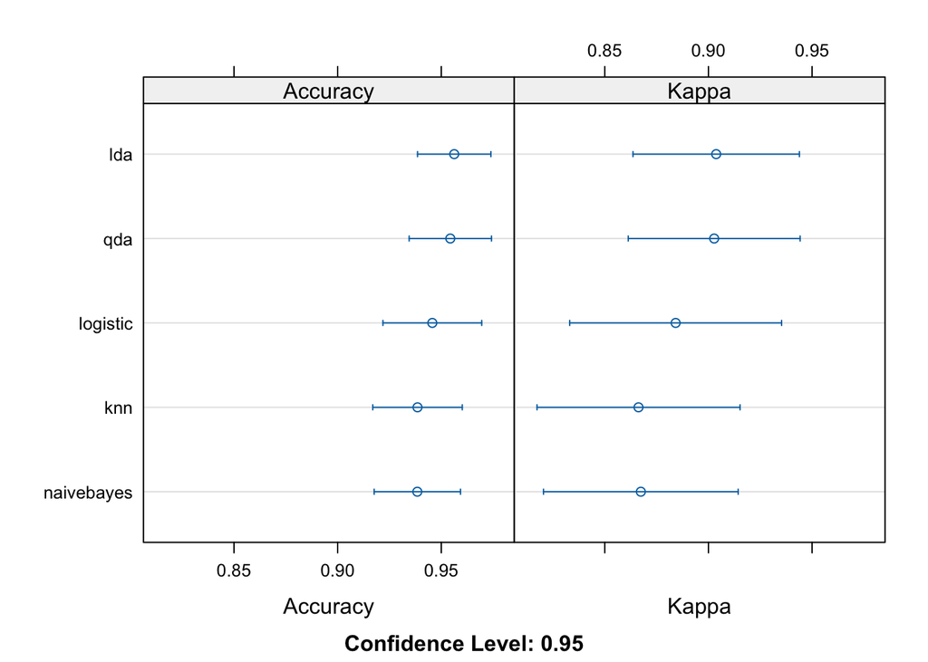

```r
# Compare models
dotplot(results)
```

It is clear that LDA and QDA are the best for prediction accuracy accompanied with the narrowest error bars followed by logistic, KNN, then naive bayes. LDA dominates QDA in terms of prediction.

## Bootstrap for classification accuracy (for LDA and QDA)

### LDA

```r
set.seed(1)
bootstrap_lda <- function(data, indices) {
  boot_data <- data[indices, ]
  test_data <- data[-indices, ]
  fit <- lda(diagnosis ~ ., data = boot_data)
  predictions <- predict(fit, test_data)$class
  accuracy <- mean(predictions == test_data$diagnosis)
  return(accuracy)
}

results <- boot(data = data, statistic = bootstrap_lda, R = 1000)

boot_mean_accuracy_lda <- mean(results$t)
boot_se_accuracy_lda <- sd(results$t)

boot_mean_accuracy_lda
```

```
## [1] 0.9529731
```

```r
boot_se_accuracy_lda
```

```
## [1] 0.01404106
```

We accurately classify about 95.30% of cases over 1000 bootstrap samples. We also have low SE relative to accuracy indicating the the model performance is quite stable

### QDA

```r
set.seed(1)
bootstrap_qda <- function(data, indices) {
  boot_data <- data[indices, ]
  test_data <- data[-indices, ]
  fit <- qda(diagnosis ~ ., data = boot_data)
  predictions <- predict(fit, test_data)$class
  accuracy <- mean(predictions == test_data$diagnosis)
  return(accuracy)
}

results <- boot(data = data, statistic = bootstrap_qda, R = 1000)

boot_mean_accuracy <- mean(results$t)
boot_se_accuracy <- sd(results$t)

boot_mean_accuracy
```

```
## [1] 0.9527565
```

```r
boot_se_accuracy
```

```
## [1] 0.01342147
```

We accurately classify about 95.27% of cases over 1000 bootstrap samples. We also have low SE relative to accuracy indicating the the model performance is quite stable

## Linear Model Selection

Previously we fit the models using all available predictors. However, now we seek to simplify the model while balancing predictive accuracy. We utilize best subset selection, forward step-wise selection, and backward step-wise selection. The best models were evaluated using adjusted R^2, Cp, and BIC.

### Best subset selection

```r
set.seed(1)
best_subset <- regsubsets(diagnosis ~ ., data=data, nvmax=ncol(data)-1)
reg.summary <- summary(best_subset)
reg.summary
```

```
## Subset selection object
## Call: regsubsets.formula(diagnosis ~ ., data = data, nvmax = ncol(data) -
##     1)
## 30 Variables  (and intercept)
##                         Forced in Forced out
## radius_mean                 FALSE      FALSE
## texture_mean                FALSE      FALSE
## perimeter_mean              FALSE      FALSE
## area_mean                   FALSE      FALSE
## smoothness_mean             FALSE      FALSE
## compactness_mean            FALSE      FALSE
## concavity_mean              FALSE      FALSE
## concave.points_mean         FALSE      FALSE
## symmetry_mean               FALSE      FALSE
## fractal_dimension_mean      FALSE      FALSE
```

[output cut: 270 more lines]

The best 1 variable model uses concave.points_worst. The best 2 variable model uses concave.points_worst and radius_worst. The best 5 variable model uses area_worst, radius_worst, texture_worst, concave.points_mean, and perimeter_mean. This highlights how best subset selected each additional variable subject to the greatest reduction in RSS. Though concave.points_worst was the best variable that captured the most amount of variation in diagnosis, when more predictors are added we see in the 5 variable model that it does not include this varialbe.

We plot RSS, adjusted R^2, C_p, and BIC at once to pick the best model. We was a high adjusted R^2, low Cp, and low BIC. The maximums/minimums are pointed out on the graph to show a visual representation of the optimal model flexibility.

```r
par(mfrow=c(2,2))

#RSS graph
plot(reg.summary$rss, xlab = "Number of Variables", ylab = "RSS", type = "l")

#adjusted R^2 graph
plot(reg.summary$adjr2, xlab = "Number of Variables",
     ylab = "Adjusted RSq", type = "l")

#We can use the points() function to put points on an already created plot, instead of a new plot. The which.max() function will identify the maximum point of a vector for us. We will use them together to mark the point with the largest adjusted R^2, smallest Cp, and smallest BIC

which.max(reg.summary$adjr2)
```

```
## [1] 14
```

```r
points(14, reg.summary$adjr2[14], col = "red", cex = 2, pch=20)

#Cp graph
plot(reg.summary$cp, xlab = "Number of Variables",
     ylab = "Cp", type = "l")
which.min(reg.summary$cp)
```

```
## [1] 14
```

```r
points(14, reg.summary$cp[14], col = "red", cex = 2, pch=20)

#BIC graph
plot(reg.summary$bic, xlab = "Number of Variables",
     ylab = "BIC", type = "l")
which.min(reg.summary$bic)
```

```
## [1] 11
```

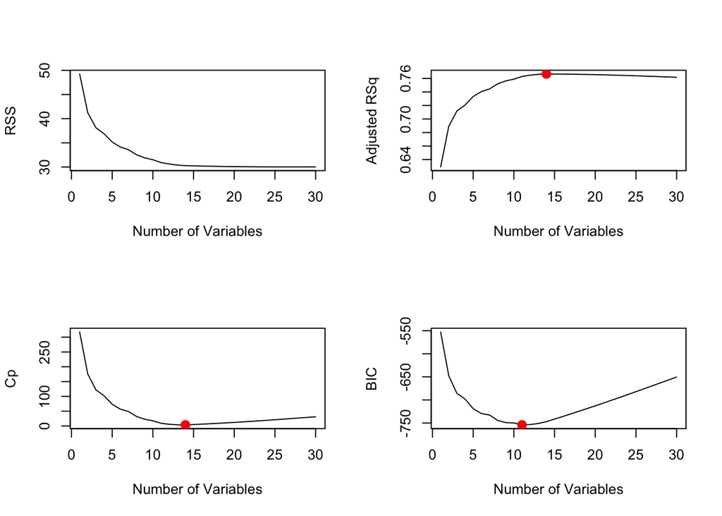

```r
points(11, reg.summary$bic[11], col = "red", cex = 2, pch=20)
```

```r
reg.summary$adjr2[11]
```

```
## [1] 0.762951
```

The 11 variable model has the lowest BIC and all other models have higher degrees of freedom so we determine that the 11 variable model is the best one chosen through best subset selection. This 11 variable model still captures 76.30% of the variation in diagnosis which is not bad prediction but must also take into account the huge reduction of bias by only using 11/29 of the predictors.

Coefficient estimates of the 11 variable model

```r
coef(best_subset, 11)
```

```
##             (Intercept)        compactness_mean          concavity_mean
##           -1.2497648180           -3.3536207560            2.1943813864
##               radius_se           smoothness_se            concavity_se
##            0.2631725214           21.4413368640           -2.7320409775
##            radius_worst           texture_worst              area_worst
##            0.1411606615            0.0105483309           -0.0009122924
##    concave.points_worst          symmetry_worst fractal_dimension_worst
##            2.2126373979            0.7988058862            4.2596208341
```

We see that smoothness_se has the largest coefficient estimate and holding all other variables constant has the largest effect of a particular cancer being malignant. Other notable variables that contribute positively to a particular cancer being malignant include fractal_dimension_worst, concavity_mean, and concave.points_worst. Notable variables that contribute negative to a particular cancer being malignant, that is, contribute to predicting a benign cancer include compactness_mean, and concavity_se.

### Forward Stepwise Selection

```r
forward_step <- regsubsets(diagnosis ~ ., data=data, method="forward", nvmax=ncol(data)-1)
reg.summary2 <- summary(forward_step)
reg.summary2
```

```
## Subset selection object
## Call: regsubsets.formula(diagnosis ~ ., data = data, method = "forward",
##     nvmax = ncol(data) - 1)
## 30 Variables  (and intercept)
##                         Forced in Forced out
## radius_mean                 FALSE      FALSE
## texture_mean                FALSE      FALSE
## perimeter_mean              FALSE      FALSE
## area_mean                   FALSE      FALSE
## smoothness_mean             FALSE      FALSE
## compactness_mean            FALSE      FALSE
## concavity_mean              FALSE      FALSE
## concave.points_mean         FALSE      FALSE
## symmetry_mean               FALSE      FALSE
## fractal_dimension_mean      FALSE      FALSE
```

[output cut: 270 more lines]

The best 1 variable model uses concave.points_worst like best subset. The best 2 variable model uses concave.points_worst and radius_worst like best subset. The best 5 variable model uses concave.points_worst, radius_worst, smoothness_se, texture_worst, and area_worst which is a little different from the best subset 5 variable model. This is a characteristic of forward step-wise selection in that variables selected in earlier stages necessarily must be included in later models unlike best subset.

We plot RSS, adjusted R^2, C_p, and BIC at once to pick the best model. We was a high adjusted R^2, low Cp, and low BIC. The maximums/minimums are pointed out on the graph to show a visual representation of the optimal model flexibility.

```r
par(mfrow=c(2,2))

#RSS graph
plot(reg.summary2$rss, xlab = "Number of Variables", ylab = "RSS", type = "l")

#adjusted R^2 graph
plot(reg.summary2$adjr2, xlab = "Number of Variables",
     ylab = "Adjusted RSq", type = "l")
which.max(reg.summary2$adjr2)
```

```
## [1] 17
```

```r
points(17, reg.summary2$adjr2[17], col = "red", cex = 2, pch=20)

#Cp graph
plot(reg.summary2$cp, xlab = "Number of Variables",
     ylab = "Cp", type = "l")
which.min(reg.summary2$cp)
```

```
## [1] 16
```

```r
points(16, reg.summary2$cp[16], col = "red", cex = 2, pch=20)

#BIC graph
plot(reg.summary2$bic, xlab = "Number of Variables",
     ylab = "BIC", type = "l")
which.min(reg.summary2$bic)
```

```
## [1] 11
```

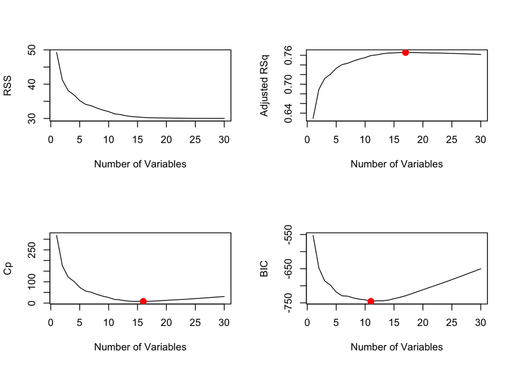

```r
points(11, reg.summary2$bic[11], col = "red", cex = 2, pch=20)
```

```r
reg.summary2$adjr2[11]
```

```
## [1] 0.759456
```

The 11 variable model has the lowest BIC and all other models have higher degrees of freedom. This 11 variable model is different from the 11 variable obtained through best subset selection. This 11 variable model obtained by forward stepwise selection captures 75.94% of the variation in diagnosis which is worse than best subset.

Coefficient estimates of the 11 variable model

```r
coef(forward_step, 11)
```

```
##             (Intercept)        compactness_mean     concave.points_mean
##            -1.336163535            -2.673310799             3.469764339
##               radius_se           smoothness_se          compactness_se
##             0.242822125            19.694457192            -1.873658146
##            radius_worst           texture_worst              area_worst
##             0.136618564             0.011868750            -0.000863892
##    concave.points_worst          symmetry_worst fractal_dimension_worst
##             1.702442719             0.843513389             5.028660265
```

### Backward Stepwise Selection

```r
backward_step <- regsubsets(diagnosis ~ ., data=data, method="backward", nvmax=ncol(data)-1)
reg.summary3 <- summary(backward_step)
reg.summary3
```

```
## Subset selection object
## Call: regsubsets.formula(diagnosis ~ ., data = data, method = "backward",
##     nvmax = ncol(data) - 1)
## 30 Variables  (and intercept)
##                         Forced in Forced out
## radius_mean                 FALSE      FALSE
## texture_mean                FALSE      FALSE
## perimeter_mean              FALSE      FALSE
## area_mean                   FALSE      FALSE
## smoothness_mean             FALSE      FALSE
## compactness_mean            FALSE      FALSE
## concavity_mean              FALSE      FALSE
## concave.points_mean         FALSE      FALSE
## symmetry_mean               FALSE      FALSE
## fractal_dimension_mean      FALSE      FALSE
```

[output cut: 270 more lines]

We plot RSS, adjusted R^2, C_p, and BIC at once to pick the best model. We was a high adjusted R^2, low Cp, and low BIC. The maximums/minimums are pointed out on the graph to show a visual representation of the optimal model flexibility.

```r
par(mfrow=c(2,2))

#RSS graph
plot(reg.summary3$rss, xlab = "Number of Variables", ylab = "RSS", type = "l")

#adjusted R^2 graph
plot(reg.summary3$adjr2, xlab = "Number of Variables",
     ylab = "Adjusted RSq", type = "l")
which.max(reg.summary3$adjr2)
```

```
## [1] 14
```

```r
points(14, reg.summary3$adjr2[14], col = "red", cex = 2, pch=20)

#Cp graph
plot(reg.summary3$cp, xlab = "Number of Variables",
     ylab = "Cp", type = "l")
which.min(reg.summary3$cp)
```

```
## [1] 14
```

```r
points(14, reg.summary3$cp[14], col = "red", cex = 2, pch=20)

#BIC graph
plot(reg.summary3$bic, xlab = "Number of Variables",
     ylab = "BIC", type = "l")
which.min(reg.summary3$bic)
```

```
## [1] 12
```

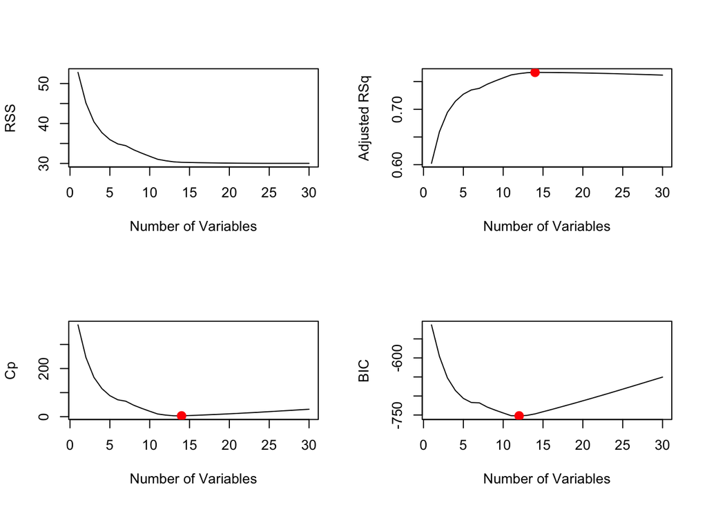

```r
points(12, reg.summary3$bic[12], col = "red", cex = 2, pch=20)
```

```r
reg.summary3$adjr2[11]
```

```
## [1] 0.7620131
```

Coefficient estimates of the 12 variable model

```r
coef(backward_step, 12)
```

```
##             (Intercept)        compactness_mean     concave.points_mean
##           -1.2009583920           -3.4311367779            4.3312698457
##               radius_se           smoothness_se            concavity_se
##            0.2445478641           19.6846410724           -3.3763472771
##       concave.points_se            radius_worst           texture_worst
##            8.6073749937            0.1329348567            0.0107315318
##              area_worst         concavity_worst          symmetry_worst
##           -0.0008398181            0.6866629356            0.8979202063
## fractal_dimension_worst
##            4.0740592992
```

The main takeaway from the subset selection methods is that over half of the variables were not necessary to capture the majority of the variation in diagnosis. A more thorough analysis utilizing cross validation to estimate test error is necessary to determine which of these models performs the best but we use mathematical adjustments to performance metrics (adjusted R^2, Cp, and BIC) to determine this. All of these subset selection methods capture about 75% of the variation in diagnosis so we can expect to accurately classify an observation to as malignant or benign about 75% of the time when using less than half of the available predictors. This shows the power of a small number of the predictors in determining which cancers are malignant and can be used in practice. For example, doctors can look at the metrics first when they have diagnostic data on a tumor and expect to accurately determine if the tumor is malignant 75% of the time which is significant because doctors now only need to consider about 11 or 12 characteristics instead of 29 which is a great improvement!

## Regularization (Ridge and Lasso)

### Ridge

```r
x <- as.matrix(data[,-1])
y <- data$diagnosis
y <- as.numeric(data$diagnosis)

# Set up lambda values for ridge regression
grid <- 10^seq(10, -2, length = 100)
ridge.mod <- glmnet(x, y, alpha = 0, lambda = grid, family = "binomial")
ridge.mod
```

```
##
## Call:  glmnet(x = x, y = y, family = "binomial", alpha = 0, lambda = grid)
##
##     Df  %Dev    Lambda
## 1   30  0.00 1.000e+10
## 2   30  0.00 7.565e+09
## 3   30  0.00 5.722e+09
## 4   30  0.00 4.329e+09
## 5   30  0.00 3.275e+09
## 6   30  0.00 2.477e+09
## 7   30  0.00 1.874e+09
## 8   30  0.00 1.417e+09
## 9   30  0.00 1.072e+09
## 10  30  0.00 8.111e+08
## 11  30  0.00 6.136e+08
```

[output cut: 89 more lines]

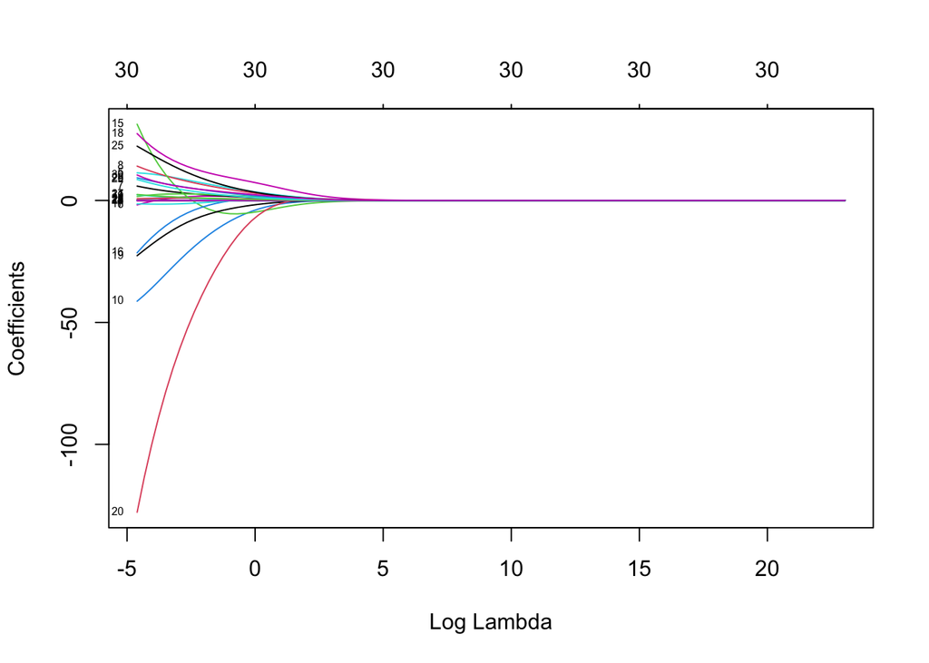

```r
# Plotting the coefficients
plot(ridge.mod, xvar = "lambda", label = TRUE)
```

This plot shows how ridge shrinks some of the coefficient estimates toward 0, some faster than others. This is one of the advantages of ridge of subset selection methods is that it will include all variables though less important variables will be shrunk toward 0 and have marginal impact on diagnosis.

Now, we determine how this model performs by calculating and estimate of the test error

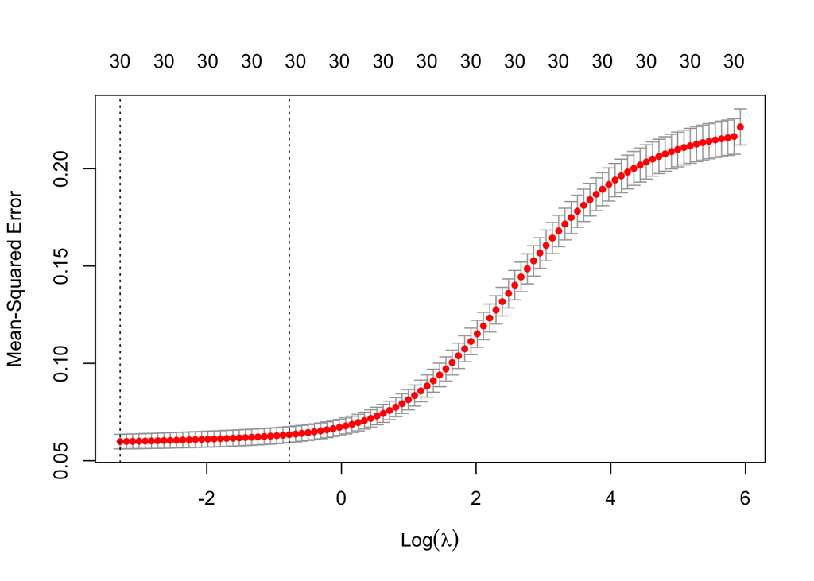

```r
#split data into training and test set
set.seed(1)
train <- sample(1:nrow(x), nrow(x) / 2)
test <- (-train)
y.test <- y[test]

#perform CV to determine optimal tuning parameter
set.seed(1)
cv.out <- cv.glmnet(x[train,], y[train], alpha = 0)
plot(cv.out)
```

This plot shows how the test error increases as lamda (the shrinkage penalty) increases. As this shrinkage penalty increases, ridge regression esimates approach 0 and the model eventually reduces to the null model with no predictors which explans why test error grows so sharply. If we have gradually have less and less predictors, then we will not be able to explain the variation in diagnosis and hence the test error will be very high.

```r
#lambda that minimizes the test MSE
bestlam <- cv.out$lambda.min
bestlam
```

```
## [1] 0.03739526
```

```r
#test MSE associated with this lambda
ridge.pred <- predict(ridge.mod, s=bestlam, newx = x[test,])
mean((ridge.pred - y.test)^2)
```

```
## [1] 22.65428
```

```r
#Now, we will refit the ridge regression on the full dataset, using our selected lambda value
out <- glmnet(x, y, alpha=0)
predict(out, type = "coefficients", s = bestlam)[1:30,]
```

```
##            (Intercept)            radius_mean           texture_mean
##          -1.648185e-01           1.275925e-02           6.600489e-03
##         perimeter_mean              area_mean        smoothness_mean
##           1.460865e-03          -4.219447e-05          -1.807198e-01
##       compactness_mean         concavity_mean    concave.points_mean
##          -9.228604e-01           3.908070e-01           1.608593e+00
##          symmetry_mean fractal_dimension_mean              radius_se
##          -1.085241e-01          -6.777338e+00           2.775752e-01
##             texture_se           perimeter_se                area_se
##           1.434615e-03           5.473914e-03          -1.349564e-03
##          smoothness_se         compactness_se           concavity_se
##           9.655898e+00          -2.048442e+00          -1.545648e+00
##      concave.points_se            symmetry_se   fractal_dimension_se
##           5.754519e+00           5.045417e-01           8.985516e-01
##           radius_worst          texture_worst        perimeter_worst
##           1.570363e-02           6.745204e-03           1.314678e-03
##             area_worst       smoothness_worst      compactness_worst
##          -3.026154e-05           1.557670e+00           4.171859e-02
##        concavity_worst   concave.points_worst         symmetry_worst
##           2.577799e-01           1.072949e+00           8.109212e-01
```

Ridge has shrunk radius_mean, texture_mean, perimeter_mean, area_mean, smoothness_mean, texture_se, perimeter_se, area_se, radius_worst, texture_worst, perimeter_worst, area_worst, and compactness_worst toward 0. For a total of 13 variables that are very close to 0. Other variable are also notably close to 0 as well. This is similar to the subset selection methods in that many of the predictors are not very useful in the prediction of malignant tumors.

### The Lasso

```r
lasso.mod <- glmnet(x, y, alpha = 1, lambda = grid, family = "binomial")
lasso.mod
```

```
##
## Call:  glmnet(x = x, y = y, family = "binomial", alpha = 1, lambda = grid)
##
##     Df  %Dev    Lambda
## 1    0  0.00 1.000e+10
## 2    0  0.00 7.565e+09
## 3    0  0.00 5.722e+09
## 4    0  0.00 4.329e+09
## 5    0  0.00 3.275e+09
## 6    0  0.00 2.477e+09
## 7    0  0.00 1.874e+09
## 8    0  0.00 1.417e+09
## 9    0  0.00 1.072e+09
## 10   0  0.00 8.111e+08
## 11   0  0.00 6.136e+08
```

[output cut: 89 more lines]

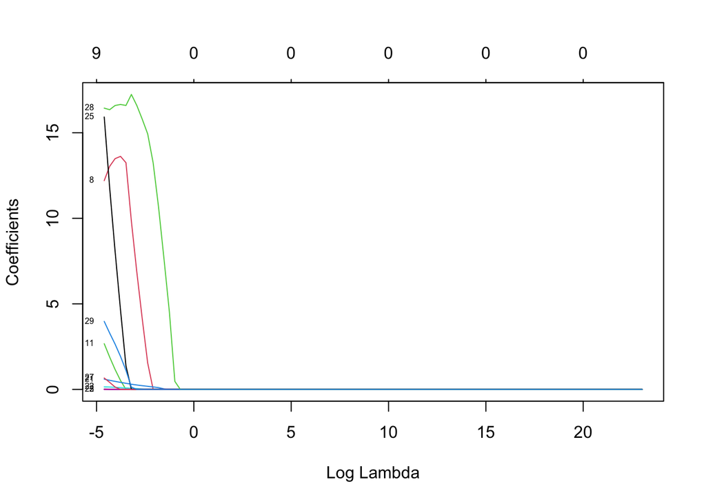

```r
# Plotting the coefficient profiles
plot(lasso.mod, xvar = "lambda", label = TRUE)
```

This plot shows how lambda forces some of the coefficient estimates to be exactly 0, some faster than others.

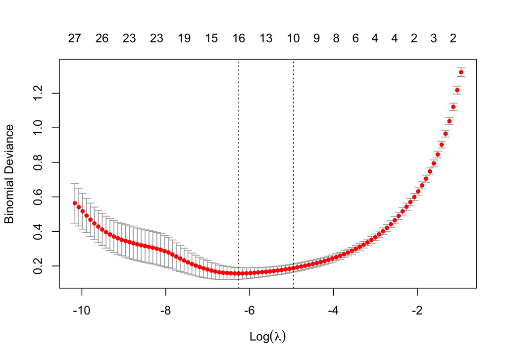

```r
# Cross-validation to find the optimal lambda
cv.lasso <- cv.glmnet(x, y, alpha = 1, family = "binomial")
plot(cv.lasso)
```

```r
bestlam <- cv.lasso$lambda.min
bestlam
```

```
## [1] 0.001909601
```

This plot shows the binomial deviance at a certain lamda value. We want a small deviaince and we select the optimal cross-validated lamda such that this deviance is minimized.

```r
#test error associated with this lambda
lasso.pred <- predict(lasso.mod, s = bestlam, newx = x[test,])
mean((lasso.pred - y.test)^2)
```

```
## [1] 28.23138
```

```r
out <- glmnet(x, y, alpha = 1, lambda = grid)
lasso.coef <- predict(out, type = "coefficients", s = bestlam)[1:30,]
lasso.coef
```

```
##            (Intercept)            radius_mean           texture_mean
##           -0.073644049            0.000000000            0.004557836
##         perimeter_mean              area_mean        smoothness_mean
##            0.000000000            0.000000000            0.000000000
##       compactness_mean         concavity_mean    concave.points_mean
##            0.000000000            0.000000000            1.193485124
##          symmetry_mean fractal_dimension_mean              radius_se
##            0.000000000           -2.123884114            0.065568802
##             texture_se           perimeter_se                area_se
##            0.000000000            0.000000000            0.000000000
##          smoothness_se         compactness_se           concavity_se
##            3.176858843            0.000000000           -0.094506148
##      concave.points_se            symmetry_se   fractal_dimension_se
##            0.000000000            0.000000000            0.000000000
##           radius_worst          texture_worst        perimeter_worst
##            0.034563273            0.008311333            0.000000000
##             area_worst       smoothness_worst      compactness_worst
##            0.000000000            1.452903349            0.000000000
##        concavity_worst   concave.points_worst         symmetry_worst
##            0.036772192            1.921945905            0.651744789
```

```r
#Looking just at the non-zero coefficients
lasso.coef[lasso.coef != 0]
```

```
##            (Intercept)           texture_mean    concave.points_mean
##           -0.073644049            0.004557836            1.193485124
## fractal_dimension_mean              radius_se          smoothness_se
##           -2.123884114            0.065568802            3.176858843
##           concavity_se           radius_worst          texture_worst
##           -0.094506148            0.034563273            0.008311333
##       smoothness_worst        concavity_worst   concave.points_worst
##            1.452903349            0.036772192            1.921945905
##         symmetry_worst
##            0.651744789
```

As we have seen through the subset selection methods and regularization methods, many of the variables are not necessary to include and most of the variables in the final models are the same across the board in these models signifiying the importance of these variables.

In the linear model selections and regularization models we must be careful not to overstate the result obtained in dimension reduction/shrinkage. What we have obtained here is simply a few out of many possible models for predicition and these models must be validated on more independent data set to reach a definitive conclusion.

## Tree-based Methods

### Classification trees

```r
set.seed(1)
tree.fit <- tree(diagnosis ~ ., data = data)

summary(tree.fit)
```

```
##
## Classification tree:
## tree(formula = diagnosis ~ ., data = data)
## Variables actually used in tree construction:
## [1] "perimeter_worst"      "concave.points_worst" "radius_se"
## [4] "texture_worst"        "symmetry_worst"       "smoothness_worst"
## [7] "radius_mean"          "smoothness_mean"
## Number of terminal nodes:  12
## Residual mean deviance:  0.09294 = 51.77 / 557
## Misclassification error rate: 0.01757 = 10 / 569
```

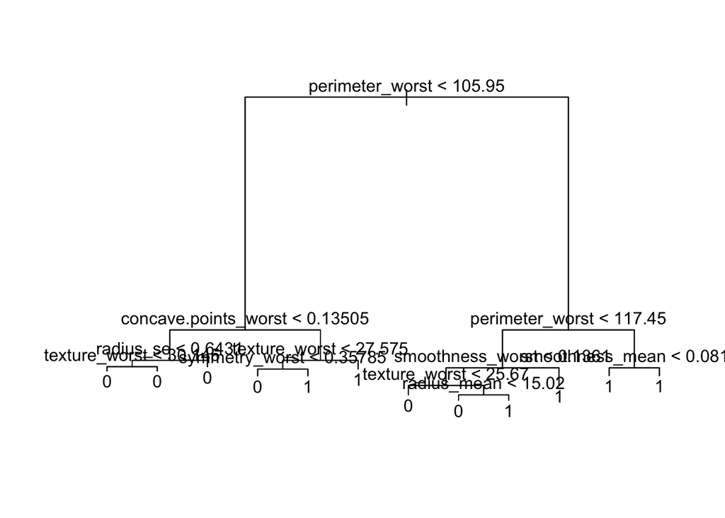

```r
plot(tree.fit)
text(tree.fit, pretty = 0)
```

Decision trees have a major advantage over other types of models in that they are easier to interpret and they provide a easy-to-decipher graph. This plot shows that the varialbe perimeter_worst appears to be the most important criterion for prediction of the diagnosis of malignant or benign tumors but this is on the training data. This variable was not included in any of the subset selection methods or the lasso. In ridge regression this variable was shrunk to a number very close to 0 (1.314678e-03).

```r
# Predictions on the training data
tree.pred <- predict(tree.fit, data, type = "class")

#confusion matrix
table(tree.pred, data$diagnosis)
```

```
##
## tree.pred   0   1
##         0 353   6
##         1   4 206
```

206+353/569 = .9824or 98.24% correctly predicted on the training data so this tree fits the training data very well.

To evaluate how well the classification tree does on this data, we will estimate the test error

```r
#Splitting the data (280 becuase it is approximately half of the observations)
set.seed(1)
train <- sample(1:nrow(data), 280)
traindata <- data[train, ]
testdata <- data[-train, ]

#Fitting the model on the training data
tree.fit <- tree(diagnosis ~ ., data = traindata)

#To get class predictions, we will set type = "class"
tree.pred <- predict(tree.fit, testdata,
                     type = "class")

#Creating the confusion matrix
table(tree.pred, testdata$diagnosis)
```

```
##
## tree.pred   0   1
##         0 162  21
##         1   7  99
```

```r
          #actual
#tree.pred   0   1
#         0 162  21
#         1   7  99
#99+162/289 = .9031 or 90.31% correctly predicted

#cross-validation to determine the optimal level of tree complexity by cost-complexity pruning
set.seed(1)
cv.fit <- cv.tree(tree.fit, FUN = prune.misclass)
names(cv.fit)
```

```
## [1] "size"   "dev"    "k"      "method"
```

```r
cv.fit
```

```
## $size
## [1] 8 7 4 2 1
##
## $dev
## [1] 21 21 22 23 92
##
## $k
## [1]      -Inf  0.000000  1.666667  3.000000 76.000000
##
## $method
## [1] "misclass"
##
## attr(,"class")
## [1] "prune"         "tree.sequence"
```

The trees with 7 and 8 terminal nodes have the lowest CV errors. We can see this as the trees with 7 or 8 terminal nodes have the lowest dev value (number of CV errors) equal to 21. K tells us the value of the cost-complexity parameter used (it corresponds to the alpha parameter)

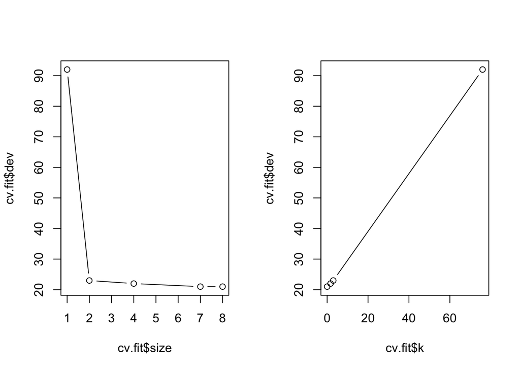

```r
#Plotting the error rate as a function of size and k
par(mfrow=c(1,2))
plot(cv.fit$size, cv.fit$dev, type = "b")
plot(cv.fit$k, cv.fit$dev, type = "b")
```

These plots show that as the size increases to 8 terminal nodes, the error rate decreases and that as the value of the cost-complexity parameter increases, the error rate increases.

Now we prune the tree to have 7 terminal nodes because the trees with 7 and 8 terminal nodes have the same number of CV errors and a simpler model is often better.

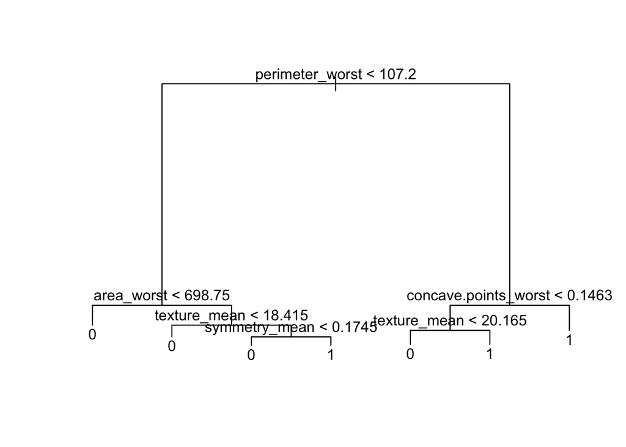

```r
prune.fit <- prune.misclass(tree.fit, best = 7)
plot(prune.fit)
text(prune.fit, pretty = 0)
```

```r
#We will use predict() again to see how well this tree performs
tree.pred <- predict(prune.fit, testdata,
                     type = "class")
table(tree.pred, testdata$diagnosis)
```

```
##
## tree.pred   0   1
##         0 162  21
##         1   7  99
```

162+99/289 = 0.9031 or 90.31% correctly predicted so this tree performs quite well on the test data.

### Bagging

```r
set.seed(1)
bagging.model <- randomForest(diagnosis ~ ., data = traindata, mtry = ncol(traindata) - 1)
bagging.pred <- predict(bagging.model, newdata = testdata)
table(bagging.pred, testdata$diagnosis)
```

```
##
## bagging.pred   0   1
##            0 161  10
##            1   8 110
```

161+110/289 = .9377 or 93.77% correctly predicted. Bagging improves upon the classification tree

### Random Forests

```r
set.seed(1)
rf.model <- randomForest(diagnosis ~ ., data = traindata)
rf.pred <- predict(rf.model, newdata = testdata)
table(rf.pred, testdata$diagnosis)
```

```
##
## rf.pred   0   1
##       0 164  12
##       1   5 108
```

#164+108/289 = .9412 or 94.12% correctly predicted. Random forests performs the best out of all the tree-based methods.

## Conclusion

#### Clinical Implications

Integrating these models into diagnositc tools can significantly improve the accuracy of breat cancer diagnoses and lessening the strain on the health care system. Our models provide predictions accuracy above 90% – and if this holds in the real world – provides a novel approach to improving treatment outcomes and survival rates. The insights of these models can also inform clinicans about the agressiveness and other characteristics of the tumor which will lead to optimal treatment planning, beter patient outcomes, and more efficient healthcare delivery.